# Modelos lineales generalizados (GLMs)

## Introducción

1. Definición
2. Estructura

   2.1. Función de vínculo

   2.2. Familia de distribución de errores

## 1. Definición

Supuestos modelos lineales:

1. Los errores se distribuyen nromalmente
2. La varianza (residual) es constante
3. La variable respuesta se relaciona linealmente con la(s) variable(s) independiente(s), si alguna de estas variables es continua

Uno o varios supuestos no se cumplen.

¿Qué hacer?

GLMs: extensión modelos lineales especificando estructuras no normales de errores y varianzas no constantes.

Modelos lineales caso particular de GLMs con distribución de errores normal y varianza constante.

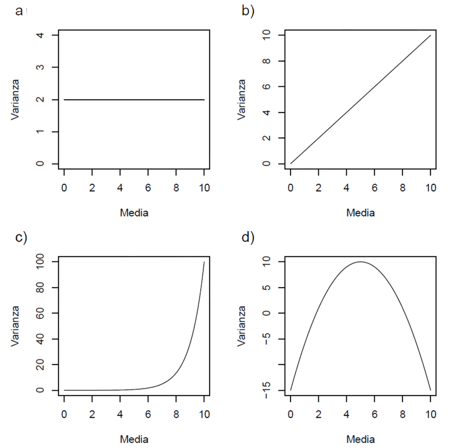

Relación varianza y media (Cayuela y de la Cruz, 2022)

Tipos de variables que por definición violan supuestos modelos lineales:

- conteo de casos (p.ej. abundancia de especies)
- conteo de casos como proporciones (p.ej. porcentaje plántulas muertas en un experimento)
- respuesta binaria (p.ej. usado o no usado, presente o ausente)

## 2. Estructura

3 componentes principales:

1. El predictor lineal

2. La función de vínculo

3. La estructura de los errores

Estructura modelos lineales:

*y<sub>i</sub> = β<sub>0</sub> + β<sub>1</sub>x<sub>1</sub> + … + β<sub>1</sub>x<sub>n</sub> + Ɛ<sub>i</sub>*

*Ɛ<sub>i</sub> ~N(0,σ<sup>2</sup>)*

Estructura GLMs:

*f(y<sub>i</sub>) = β<sub>0</sub> + β<sub>1</sub>x<sub>1</sub> + … + β<sub>1</sub>x<sub>n</sub> + Ɛ<sub>i</sub>*

*Var(y) ~ f(µ)*

##### 2.1. La función de vínculo *f(y)*

Transformación de la variable *y* buscando linealizar relación *y* con *x* y/o transformando en continuas variables que no lo son.

Por tanto, cambia la naturaleza de la variable respuesta.

Determinadas funciones de vínculo deben implementarse con determinados tipos de variables respuesta

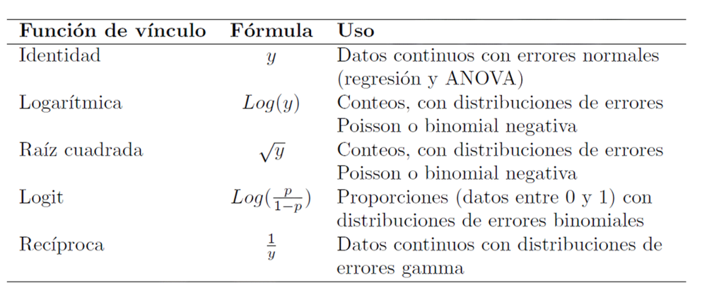

Función de vínculo (Cayuela y de la Cruz, 2022)

##### 2.2. La familia de distribución de errores

1. Poisson: varianza aumenta linealmente con la media. Para respuestas tipo conteo.
2. Binomial negativa: extensión de Poisson. Para variables conteo con sobredispersión.
3. Binomial: para proporsiones y datos presencia/ausencia.
4. Gamma: para datos continuos con coeficiente de variación constante.

#### Ajuste GLM en R

Función glm()

Argumento family:

- binominal(link = “logit”)
- gaussian(link = “identity)
- Gamma(link = “inverse”)
- inverse.gaussian(link = “1/mu^2)
- poisson(link = “log”)
- quasi(link = “identity”, variance = “constant”)

## Ejemplo con datos tipo conteo

Efecto ganadería en regeneración de araucaria. Muestreo de número de plantas de araucaria en dos tipos de ganadería: pequeños propietarios, con uso más intensivo de la tierra, y grandes empresas forestales, que mantienen algunos remanente bosque nativo. Actividad ganado medida por número de bostas.

```r
library(ADER)
data(ara)
str(ara)
```

```
'data.frame':   26 obs. of  3 variables:
 $ seedlings: int  7 10 0 5 54 0 30 14 1 2 ...
 $ dungs    : int  5 0 330 960 115 2330 475 10 2000 130 ...
 $ property : Factor w/ 2 levels "Campesino","Empresa Forestal": 2 2 2 2 2 2 2 2 2 1 ...
```

Hipótesis:

*H0: β = 0* (pendiente entre plántulas y número de bostas es 0)

*H0: µ<sub>1</sub> = µ<sub>2</sub>* (número plántulas en pequeños propietarios y empresas sin diferencias)

*H0: β<sub>1</sub> = β<sub>2</sub>* (relación entre plántulas y bostas es igual en pequeños propietarios y empresas)

### Exploración gráfica de los datos

```r
library(ggplot2)
ggplot(ara, aes(x = dungs, y = seedlings)) +
  geom_point(color = "steelblue", size = 2) +
  facet_wrap(~ property) +
  labs(
    title = "Relación nº plántulas y nº bostas",
    x = "Nº bostas",
    y = "Nº plántulas"
  ) +
  theme_minimal()
```

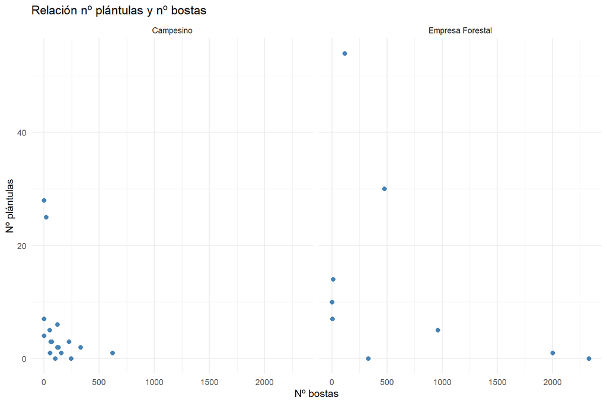

#### Construcción modelo

```r
glm_arau1 <- glm(seedlings ~ dungs*property, ara, family = "poisson")
anova(glm_arau1)
```

```
Analysis of Deviance Table

Model: poisson, link: log

Response: seedlings

Terms added sequentially (first to last)

               Df Deviance Resid. Df Resid. Dev  Pr(>Chi)
NULL                              25     347.56
dungs           1   30.967        24     316.59 2.624e-08 ***
property        1   80.598        23     236.00 < 2.2e-16 ***
dungs:property  1   37.974        22     198.02 7.170e-10 ***
---
Signif. codes:  0 '***' 0.001 '**' 0.01 '*' 0.05 '.' 0.1 ' ' 1
```

Devianza explicada por el modelo

Medida de cantidad de variabilidad que explica el modelo (similar R<sup>2</sup> en modelos lineales)

*D<sup>2</sup> = 1 - D<sub>modelo</sub>/D<sub>nulo</sub>*

```r
print(D2 <- 1 - (198.02/347.56))
```

```
[1] 0.4302566
```

```r
summary(glm_arau1)
```

```
Call:
glm(formula = seedlings ~ dungs * property, family = "poisson",
    data = ara)

Coefficients:
                                Estimate Std. Error z value Pr(>|z|)
(Intercept)                     2.497423   0.135408  18.444  < 2e-16 ***
dungs                          -0.010211   0.001789  -5.706 1.15e-08 ***
propertyEmpresa Forestal        0.576261   0.170467   3.380 0.000724 ***
dungs:propertyEmpresa Forestal  0.009041   0.001803   5.015 5.31e-07 ***
---
Signif. codes:  0 '***' 0.001 '**' 0.01 '*' 0.05 '.' 0.1 ' ' 1

(Dispersion parameter for poisson family taken to be 1)

    Null deviance: 347.56  on 25  degrees of freedom
Residual deviance: 198.02  on 22  degrees of freedom
AIC: 282.3

Number of Fisher Scoring iterations: 5
```

Fórmula: *log(y) = 2.497 + 0.576 Empresa + (-0.010 + 0.009 Empresa) Bostas*

#### Supuestos del modelo

```r
par(mfrow=c(2,2))
plot(glm_arau1)
```

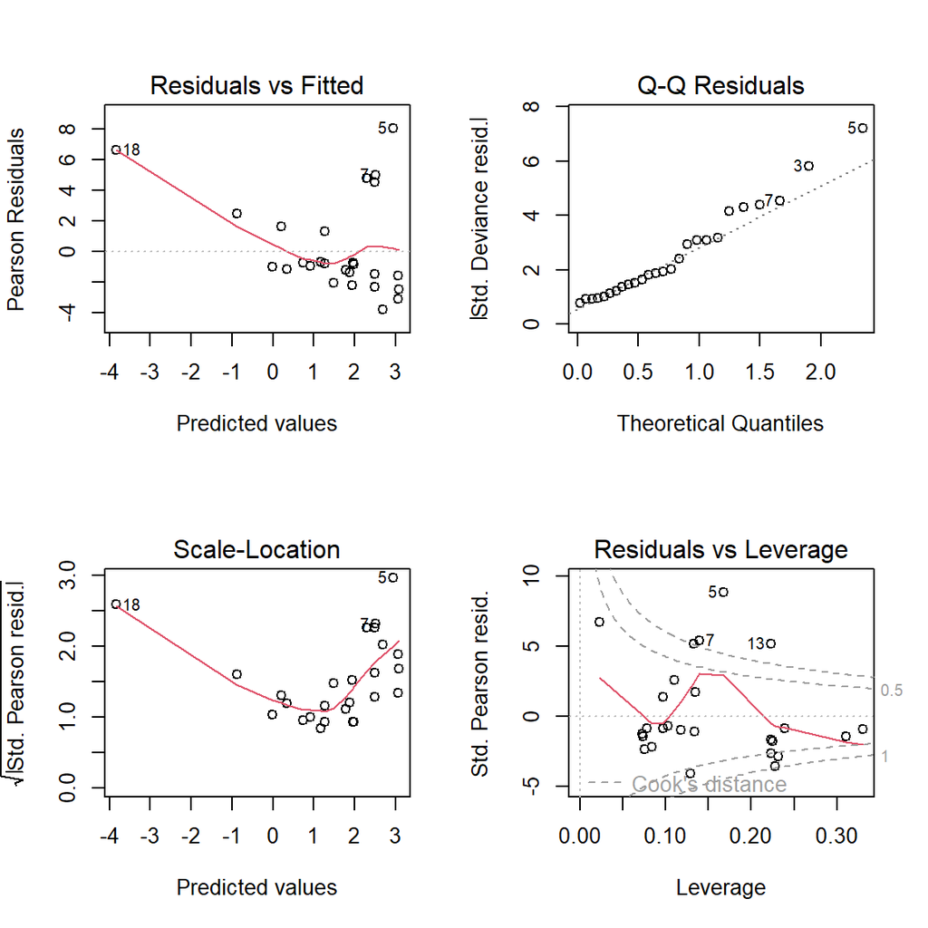

```r
library(aods3)
gof(glm_arau1)
```

```
D  = 198.022, df = 22, P(>D) = 2.772377e-30
X2 = 248.4275, df = 22, P(>X2) = 2.969764e-40
```

### Modelo binomial negativo

```r
library(MASS)
glm_arau2 <- glm.nb(seedlings ~ dungs*property, ara)
summary(glm_arau2)
```

```
Call:
glm.nb(formula = seedlings ~ dungs * property, data = ara, init.theta = 1.13715532,
    link = log)

Coefficients:
                                Estimate Std. Error z value Pr(>|z|)
(Intercept)                     2.152593   0.362295   5.942 2.82e-09 ***
dungs                          -0.005663   0.002468  -2.294   0.0218 *
propertyEmpresa Forestal        1.113371   0.557993   1.995   0.0460 *
dungs:propertyEmpresa Forestal  0.003945   0.002528   1.561   0.1186
---
Signif. codes:  0 '***' 0.001 '**' 0.01 '*' 0.05 '.' 0.1 ' ' 1

(Dispersion parameter for Negative Binomial(1.1372) family taken to be 1)

    Null deviance: 49.506  on 25  degrees of freedom
Residual deviance: 28.040  on 22  degrees of freedom
AIC: 155.22

Number of Fisher Scoring iterations: 1

              Theta:  1.137
          Std. Err.:  0.384

 2 x log-likelihood:  -145.218
```

### Supuestos del modelo

```r
par(mfrow=c(2,2))
plot(glm_arau2)
```

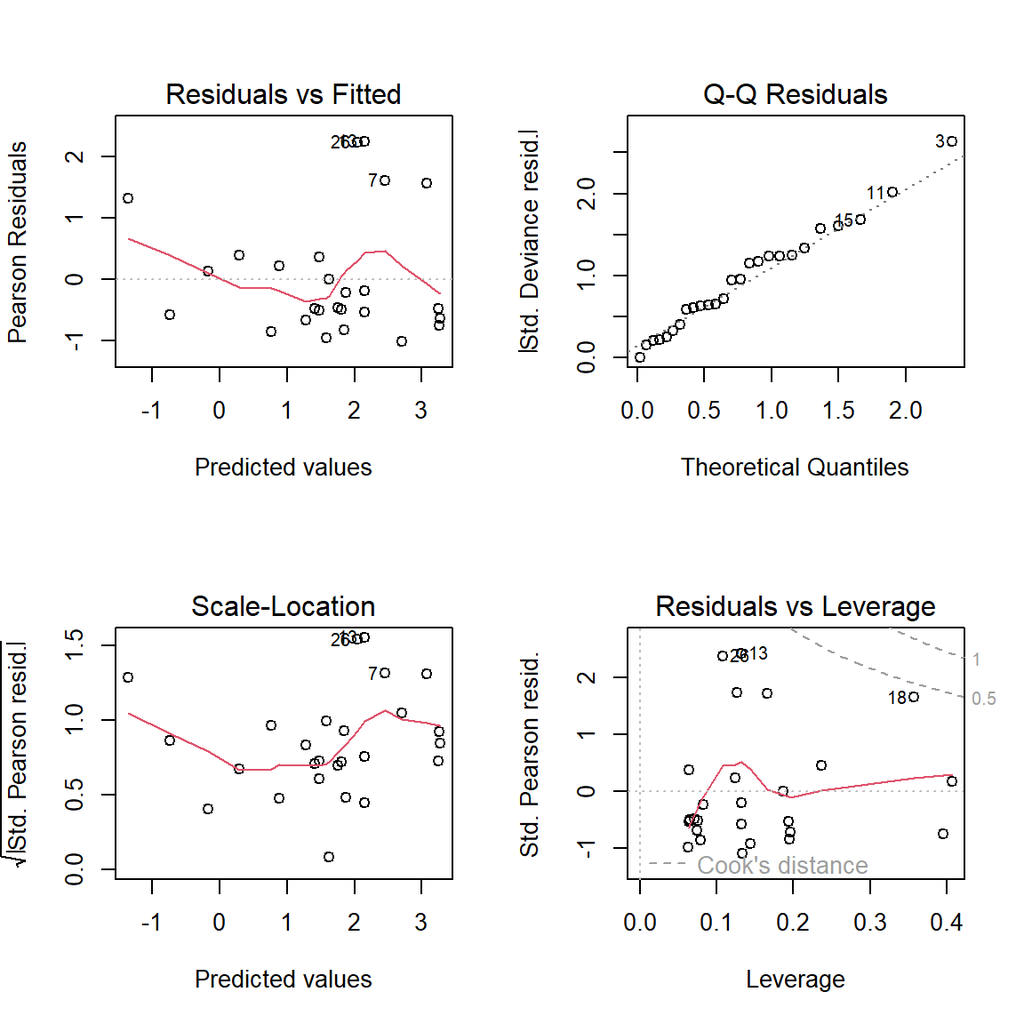

```r
gof(glm_arau2)
```

```
D  = 28.0403, df = 22, P(>D) = 0.1743489
X2 = 24.0659, df = 22, P(>X2) = 0.343783
```

#### Predicciones modelo

```r
library(car)
Anova(glm_arau2, type = "III")
```

```
Analysis of Deviance Table (Type III tests)

Response: seedlings
               LR Chisq Df Pr(>Chisq)
dungs            7.9871  1   0.004711 **
property         4.3145  1   0.037789 *
dungs:property   3.5106  1   0.060977 .
---
Signif. codes:  0 '***' 0.001 '**' 0.01 '*' 0.05 '.' 0.1 ' ' 1
```

```r
library(visreg)
visreg(glm_arau2, "dungs", by ="property", overlay = T, scale = "response", ylab = "Nº plántulas", xlab = "Nº bostas")
```

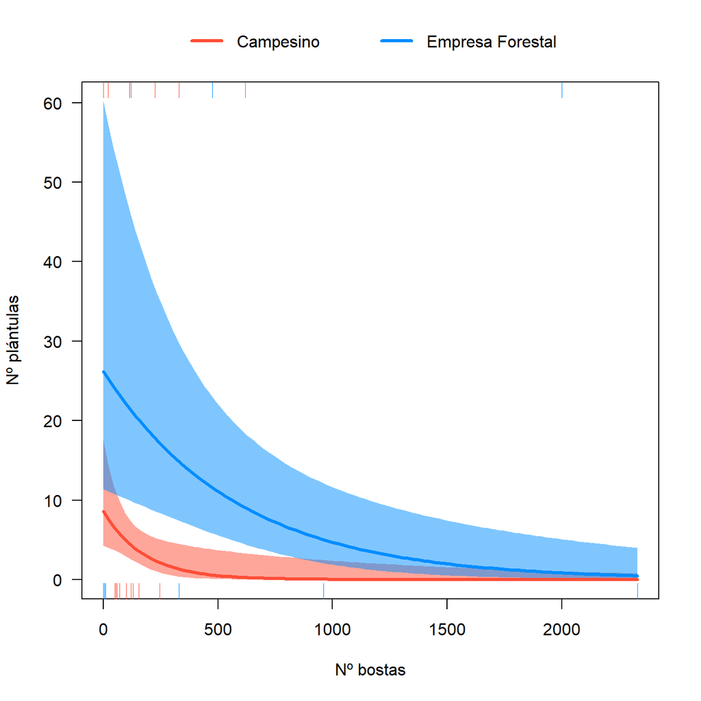

## Ejemplo con distribución de errores binomial

2 variantes de estos modelos:

- Variable con valores binarios (1/0): modelos de regresión logística
- variables con valores porcentuales (nº éxitos / nº de ensayos)

Función de vínculo: logit *log(p/(1-p))*

*logit(y) = ln(p/(1-p)) = β<sub>0</sub> + β<sub>1</sub>x<sub>1</sub> + … + β<sub>1</sub>x<sub>n</sub>*

Curva sigmoidea entre 0-1

## Ejemplo: Estrategia reproductora especie de alga invasora

Estrategia reproductora de un alga invasora con dos especies nativas.

¿Probabilidad de encontrar estructuras reproductoras es diferente entre la especie invasora y las nativas?

Hipótesis: la especie invasora tendrá mayor probabilidad de reproducrise que las nativas

```r
library(ADER)
data(algas)
str(algas)
```

```
'data.frame':   359 obs. of  3 variables:
 $ Sp    : Factor w/ 3 levels "Fra","Tom","Ver": 3 3 3 3 3 3 3 3 3 3 ...
 $ Long  : num  1 2 4 4 4 4.5 4.5 4.5 5 5 ...
 $ Estado: int  0 0 0 0 0 0 0 0 0 0 ...
```

Variable respuesta (Estado):

```
 - 0: sin estructuras reproductoras
 - 1: con estructuras reproductoras
```

Variables predictoras:

```
 - talla del individuo (cm)
 - especie (Sp)
```

#### Exploración de los datos

```r
ggplot(algas, aes(x = Long, y = Estado, color = Sp)) +
  geom_point(alpha = 0.4, position = position_jitter(height = 0.05)) +
facet_wrap(~Sp) +
  labs(
    x = "Talla individuo (cm)",
    y = "Estructura reproductora",
  ) +
  theme_minimal()
```

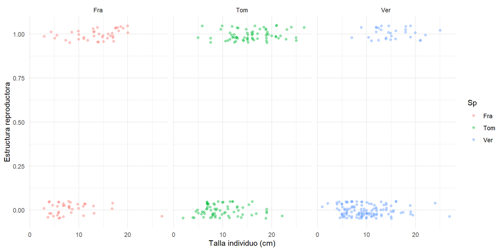